# Introdução dplyr

Ao trabalhar com dados devemos:

- Planejar toda a atividade.
- Descrever as tarefas em uma linguagem de programação.
- Executar o programa.

O pacote **dplyr** executa esses passo de forma rápida e fácil:

- Ao restringir as opções, ajuda-nos a pensar nos desafios da manipulação de dados.
- Ao fornecer “verbos”, funções que correspondem as tarefas mais comuns de manipulação, para traduzir as tarefas necessárias a análise em código.
- Backends eficientes gastam menos tempo de processamento do computador.

## Dados: enem_df

O banco de dados `enem_df` será utilizado para ilustrar os verbos disponibilizados pelo **dplyr**. O `enem_df` é compostos por 9 colunas (variáveis) e por 123169 observções, que representam todos os candidatos do ENEM no ano de 2017 que moram em Brasília. Os dados de todos de todos os candidatos do ENE e a sua documetação foram obtidos no [INEP microdados](http://www.portal.inep.gov.br/web/guest/microdados).

Os dados em `enem_df` é uma **tibble**, uma releitura moderna do conceito de **data frame**. Útil em trabalhos com grandes bases de dados. Mais informações sobre tibbles pode ser obtida em http://tibble.tidyverse.org. É possível connverter **data frames** em **tibbles** por meio de `as_tibble()`.

Nesta atividade serão usadas oito 8 vairáveis:

- NU_INSCRICAO - número de inscrição
- NU_IDADE - idade
- TP_ESCOLA - 1 não respondeu; 2 pública ; 3 privada e 4 exterior
- NU_NOTA_CN - nota de ciências da natureza
- NU_NOTA_CH - nota de ciências da humanas
- NU_NOTA_LC - nota de linguagem e código
- NU_NOTA_MT - nota de matemática
- NU_NOTA_REDACAO - nota de redação

## Verbos

O *dplyr* apresenta um **verbo** (função) para cada atividade básica de manipulação de dados:

- `filter()` para selecionar observações com base nos seus valores.
- `arrange()` para ordenar as observações .
- `select()` e `rename()` para selecionar variáveis com base em seus nomes.
- `mutate()` e `transmute()` para adicionar novas variavéis que são funções das variáveis existentes.
- `summarise()` para condensar multiplos valores em um unico valor.
- `sample_n()` e `sample_frac()` para retirar amostras aleatórias.

### Seleção de colunas com `select()`

Ao trabalhar com um grande banco de dados com muitas colunas é comum ter interesse em um conjunto menor delas. O verbo `select()` possibilita de uma forma precisa selecionar um grupo de colunas.

Para selecionar selecionar as variaveis NU_INSCRICAO , NU_IDADE, TP_ESCOLA, NU_NOTA_CN, NU_NOTA_CH, NU_NOTA_LC, NU_NOTA_MT e NU_NOTA_REDACAO.

```r
# Seleciona as variáveis por nome
#select(enem_df, TP_ENSINO, TP_ESCOLA, NU_NOTA_CN, NU_NOTA_CH, NU_NOTA_LC, NU_NOTA_MT,  NU_NOTA_REDACAO)

enem_df = select(enem_df, NU_INSCRICAO, NU_IDADE, TP_ESCOLA, NU_NOTA_CN:NU_NOTA_MT, NU_NOTA_REDACAO)
```

Há funções auxiliares para sere usada com `select()`: `starts_with()`, `ends_with()`, `matches()` e `contains()`. Essas funções selecionam rapidamente um conjunto de variáveis que atendem determinado critério. Para maiores detálhe `?select`.

```r
select(enem_df, INSCRICAO = NU_INSCRICAO)
```

| INSCRICAO |
| --- |
| 170003333552 |
| 170001665534 |
| 170001664218 |
| 170003336386 |
| 170001670034 |
| 170001663762 |
| 170003334388 |
| 170001663765 |
| 170001663770 |
| 170003333574 |

[output cut: 990 more lines]

Entretanto, o `select()` exclui todas as variáveis que não foram explicitamente mencionadas. por isso para renomear uma variável use a função rename `rename()`:

```r
rename(enem_df,  INSCRICAO = NU_INSCRICAO)
```

| INSCRICAO | NU_IDADE | TP_ESCOLA | NU_NOTA_CN | NU_NOTA_CH | NU_NOTA_LC | NU_NOTA_MT | NU_NOTA_REDACAO |
| --- | --- | --- | --- | --- | --- | --- | --- |
| 170003333552 | 23 | 1 | 462.6 | 534.8 | 561.8 | 415.5 | 740 |
| 170001665534 | 36 | 1 | NA | NA | NA | NA | NA |
| 170001664218 | 31 | 1 | NA | NA | NA | NA | NA |
| 170003336386 | 20 | 1 | 515.5 | 516.5 | 466.1 | 509.2 | 680 |
| 170001670034 | 46 | 1 | 618.5 | 662.4 | 637.3 | 613.1 | 560 |
| 170001663762 | 39 | 1 | NA | NA | NA | NA | NA |
| 170003334388 | 20 | 1 | 690.6 | 693.7 | 669.4 | 754.3 | 940 |
| 170001663765 | 43 | 1 | NA | NA | NA | NA | NA |
| 170001663770 | 25 | 1 | NA | NA | NA | NA | NA |
| 170003333574 | 32 | 1 | 512.0 | 459.3 | 432.0 | 424.1 | 480 |

[output cut: 990 more lines]

### Filtrar linhas com `filter()`

`filter()` permite selecionar um subconjunto de observações em um data frame que são verdadeiras (`TRUE`) quando submetidas a uma sentença lógica. Por exemplo, para selecionar os candidatos com 46 anos o código é:

```r
filter(enem_df, NU_IDADE == 46)
```

| NU_INSCRICAO | NU_IDADE | TP_ESCOLA | NU_NOTA_CN | NU_NOTA_CH | NU_NOTA_LC | NU_NOTA_MT | NU_NOTA_REDACAO |
| --- | --- | --- | --- | --- | --- | --- | --- |
| 170001670034 | 46 | 1 | 618.5 | 662.4 | 637.3 | 613.1 | 560 |
| 170003333834 | 46 | 1 | NA | NA | NA | NA | NA |
| 170001671369 | 46 | 1 | NA | NA | NA | NA | NA |
| 170005038793 | 46 | 1 | NA | NA | NA | NA | NA |
| 170001674639 | 46 | 1 | 581.7 | 609.7 | 600.0 | 662.6 | 480 |
| 170005036340 | 46 | 1 | NA | NA | NA | NA | NA |
| 170005057961 | 46 | 1 | NA | NA | NA | NA | NA |
| 170003337754 | 46 | 1 | 468.9 | 470.6 | 449.4 | 377.7 | 460 |
| 170001680627 | 46 | 1 | 617.1 | 556.8 | 495.0 | 545.4 | 360 |
| 170005056319 | 46 | 1 | NA | NA | NA | NA | NA |

[output cut: 509 more lines]

Esse código é equivalente aos seguinte comandos em base R:

```r
enem_df[enem_df$NU_IDADE == 46, ]
```

### Ordenar observações com `arrange()`

`arrange()` ordena as observações de um tibble (ou data frame) com base nos valores de um conjunto de vriáveis. Se for indicada mais de uma coluna, cada coluna adicionada será o critério de desempate para os valores iguais da coluna precedente:

```r
arrange(enem_df, NU_NOTA_REDACAO)
```

| NU_INSCRICAO | NU_IDADE | TP_ESCOLA | NU_NOTA_CN | NU_NOTA_CH | NU_NOTA_LC | NU_NOTA_MT | NU_NOTA_REDACAO |
| --- | --- | --- | --- | --- | --- | --- | --- |
| 170001666572 | 25 | 2 | NA | 428.1 | 394.2 | NA | 0 |
| 170003337517 | 39 | 1 | 556.0 | 585.4 | 559.2 | 568.9 | 0 |
| 170003335816 | 50 | 1 | 468.0 | 422.2 | 346.6 | 407.7 | 0 |
| 170003342917 | 18 | 2 | 465.6 | 426.0 | 415.2 | 387.0 | 0 |
| 170001664478 | 41 | 1 | 556.9 | 591.7 | 592.5 | 544.0 | 0 |
| 170001670110 | 39 | 1 | 424.4 | 402.5 | 546.7 | 412.9 | 0 |
| 170001667316 | 31 | 1 | NA | 0.0 | 578.2 | NA | 0 |
| 170001676348 | 31 | 1 | 522.8 | 565.5 | 542.3 | 534.0 | 0 |
| 170001672708 | 18 | 2 | 399.8 | 427.4 | 524.5 | 458.0 | 0 |
| 170003335921 | 22 | 1 | 517.5 | 580.5 | 569.8 | 557.4 | 0 |

[output cut: 990 more lines]

A função `desc()` ordena a coluna em ordem descedente:

```r
arrange(enem_df, desc(NU_NOTA_REDACAO))
```

| NU_INSCRICAO | NU_IDADE | TP_ESCOLA | NU_NOTA_CN | NU_NOTA_CH | NU_NOTA_LC | NU_NOTA_MT | NU_NOTA_REDACAO |
| --- | --- | --- | --- | --- | --- | --- | --- |
| 170001673531 | 17 | 2 | 586.0 | 583.9 | 595.7 | 697.1 | 980 |
| 170003377330 | 18 | 1 | 638.8 | 644.6 | 548.9 | 736.5 | 980 |
| 170005101948 | 18 | 1 | 746.1 | 735.6 | 649.3 | 972.5 | 980 |
| 170003425584 | 18 | 1 | 670.1 | 626.4 | 584.2 | 757.0 | 980 |
| 170001785806 | 17 | 3 | 703.0 | 695.4 | 664.6 | 746.8 | 980 |
| 170000125463 | 19 | 1 | 750.2 | 716.7 | 667.7 | 885.7 | 980 |
| 170001824990 | 20 | 1 | 702.2 | 659.3 | 603.0 | 728.5 | 980 |
| 170003470812 | 18 | 1 | 663.3 | 661.4 | 640.0 | 802.2 | 980 |
| 170003495388 | 18 | 3 | 630.8 | 697.4 | 657.8 | 680.1 | 980 |
| 170000156927 | 18 | 1 | 753.5 | 680.7 | 598.9 | 816.1 | 980 |

[output cut: 990 more lines]

### Criando colunas com `mutate()`

O objetivo do verbo `mutate()` é criar novas colunas a partir de outras colunas do tiblle (ou data frame).

```r
enem_df <- mutate(enem_df,
           MEDIA =  (NU_NOTA_CN + NU_NOTA_CH + NU_NOTA_LC  +
                     NU_NOTA_MT + NU_NOTA_REDACAO)/6

)
```

`mutate()` é semelhante à `transform ()` no R base, mas permite utilizar a colunas que você acabou de criar:

```r
mutate(enem_df,
  MEDIA = (NU_NOTA_CN + NU_NOTA_CH + NU_NOTA_LC  +
                   NU_NOTA_MT + NU_NOTA_REDACAO)/6,

  SIT_MT = NU_NOTA_MT/MEDIA

)
```

| NU_INSCRICAO | NU_IDADE | TP_ESCOLA | NU_NOTA_CN | NU_NOTA_CH | NU_NOTA_LC | NU_NOTA_MT | NU_NOTA_REDACAO | MEDIA | SIT_MT |
| --- | --- | --- | --- | --- | --- | --- | --- | --- | --- |
| 170003333552 | 23 | 1 | 462.6 | 534.8 | 561.8 | 415.5 | 740 | 452.4500 | 0.9183335 |
| 170001665534 | 36 | 1 | NA | NA | NA | NA | NA | NA | NA |
| 170001664218 | 31 | 1 | NA | NA | NA | NA | NA | NA | NA |
| 170003336386 | 20 | 1 | 515.5 | 516.5 | 466.1 | 509.2 | 680 | 447.8833 | 1.1369032 |
| 170001670034 | 46 | 1 | 618.5 | 662.4 | 637.3 | 613.1 | 560 | 515.2167 | 1.1899848 |
| 170001663762 | 39 | 1 | NA | NA | NA | NA | NA | NA | NA |
| 170003334388 | 20 | 1 | 690.6 | 693.7 | 669.4 | 754.3 | 940 | 624.6667 | 1.2075240 |
| 170001663765 | 43 | 1 | NA | NA | NA | NA | NA | NA | NA |
| 170001663770 | 25 | 1 | NA | NA | NA | NA | NA | NA | NA |
| 170003333574 | 32 | 1 | 512.0 | 459.3 | 432.0 | 424.1 | 480 | 384.5667 | 1.1027997 |

[output cut: 990 more lines]

Caso o objetivo seja criar um novo data frame apenascom as novas variáveis use a função `transmute()`:

```r
transmute(enem_df,
  MEDIA = (NU_NOTA_CN + NU_NOTA_CH + NU_NOTA_LC  +
                   NU_NOTA_MT + NU_NOTA_REDACAO)/6

)
```

| MEDIA |
| --- |
| 452.4500 |
| NA |
| NA |
| 447.8833 |
| 515.2167 |
| NA |
| 624.6667 |
| NA |
| NA |
| 384.5667 |

[output cut: 990 more lines]

### Resumo de valores com `summarise()`

O verbo é `summarise()` resume as os valores de um data frame por meio do resultado de uma função.

```r
summarise(enem_df,
  media = mean(NU_NOTA_REDACAO, na.rm = TRUE)
)
```

| media |
| --- |
| 541.8165 |

### Amostra aleatórioa de observações com `sample_n()` and `sample_frac()`

Os verbos `sample_n()` e `sample_frac()` retiram uma amostra aleatória de observações de um data frame. * `sample_n()` retorna uma amotra de tamanho especificado. * `sample_frac()` retorna uma amostra com o tamahho específicao com uma fração da polução.

```r
sample_n(enem_df, 12317)
```

| NU_INSCRICAO | NU_IDADE | TP_ESCOLA | NU_NOTA_CN | NU_NOTA_CH | NU_NOTA_LC | NU_NOTA_MT | NU_NOTA_REDACAO | MEDIA |
| --- | --- | --- | --- | --- | --- | --- | --- | --- |
| 170005725065 | 22 | 1 | NA | 574.6 | 422.1 | NA | 0 | NA |
| 170006102404 | 21 | 1 | NA | NA | NA | NA | NA | NA |
| 170005350416 | 18 | 2 | 549.4 | 601.2 | 564.1 | 446.2 | 740 | 483.4833 |
| 170005255310 | 19 | 1 | 524.6 | 589.6 | 549.0 | 532.2 | 720 | 485.9000 |
| 170002305225 | 22 | 1 | 532.4 | 588.4 | 553.8 | 568.4 | 600 | 473.8333 |
| 170000958571 | 18 | 2 | 411.5 | 513.0 | 437.7 | 573.9 | 520 | 409.3500 |
| 170000221435 | 17 | 2 | 448.5 | 455.8 | 561.7 | 481.9 | 560 | 417.9833 |
| 170005181896 | 30 | 1 | NA | NA | NA | NA | NA | NA |
| 170003357138 | 20 | 3 | NA | NA | NA | NA | NA | NA |
| 170000496026 | 17 | 2 | 466.2 | 548.8 | 563.1 | 540.7 | 780 | 483.1333 |

[output cut: 990 more lines]

```r
sample_frac(enem_df, 0.01)
```

| NU_INSCRICAO | NU_IDADE | TP_ESCOLA | NU_NOTA_CN | NU_NOTA_CH | NU_NOTA_LC | NU_NOTA_MT | NU_NOTA_REDACAO | MEDIA |
| --- | --- | --- | --- | --- | --- | --- | --- | --- |
| 170001985352 | 18 | 2 | 486.6 | 503.9 | 480.5 | 521.3 | 440 | 405.3833 |
| 170003582880 | 18 | 2 | 425.0 | 436.7 | 447.4 | 467.5 | 500 | 379.4333 |
| 170000193525 | 18 | 2 | NA | NA | NA | NA | NA | NA |
| 170001769307 | 28 | 1 | 432.8 | 499.9 | 535.5 | 507.7 | 560 | 422.6500 |
| 170005971387 | 22 | 1 | NA | 629.7 | 544.1 | NA | 560 | NA |
| 170005977111 | 31 | 1 | NA | 574.0 | 465.0 | NA | 500 | NA |
| 170001087562 | 24 | 1 | NA | NA | NA | NA | NA | NA |
| 170005214998 | 36 | 1 | 507.2 | 612.7 | 577.8 | 516.2 | 460 | 445.6500 |
| 170001628098 | 51 | 1 | NA | NA | NA | NA | NA | NA |
| 170006239966 | 25 | 1 | NA | NA | NA | NA | NA | NA |

[output cut: 990 more lines]

A opção `replace = TRUE` executa uma amostra com reposição. Se necessitar de uma amostra ponderada, o peso amostral deve ser informado pelo argumento `weight`.

### Observacões

Note que a sintaxe de todos esses verbos são muito semelhantes:

- O primeiro argumento é um data frame.
- Os argumentos subsequentes descrevem o que fazer com o data frame.
- Pode-se acessar os valores de uma variável sem usar $.
- O resultado é um novo data frame

Juntas, essas propriedades facilitam a interligação de várias etapas simples para alcançar um resultado complexo.

Esses cinco verbos (funções) fornecem a base de uma linguagem de manipulação de dados. No nível mais básico, é possível alterar um data frame de cinco maneiras: reordenar as observações (`arrenge ()`), selecionar observações e variáveis de interesse (`filter ()` e `select ()`. Adicionar novas variáveis que são funções de variáveis existentes (`mutate ()`), ou resumir muitos valores (`summarize ()`). O restante da linguagem vem da aplicação das cinco funções a diferentes tipos de dados.

### Operações agrupadas

Os verbos dplyr são úteis por si só, mas eles se tornam ainda mais poderoso quando aplicados a grupos de observações de um data frame. No dplyr, isso é possível com a função `group_by ()`. Essa função divide um conjunto de dados em grupos especificos de linhas. Assim, ao aplicar os verbos ao data frame eles serão automaticamente executados “por grupo”.

```r
grupo <-group_by(enem_df, TP_ESCOLA)
summarise(grupo,
  count = n(),
  media = mean(MEDIA, na.rm = TRUE)
  )
```

| TP_ESCOLA | count | media |
| --- | --- | --- |
| 1 | 91188 | 442.3776 |
| 2 | 23641 | 425.8473 |
| 3 | 8238 | 498.9435 |
| 4 | 102 | 534.4425 |

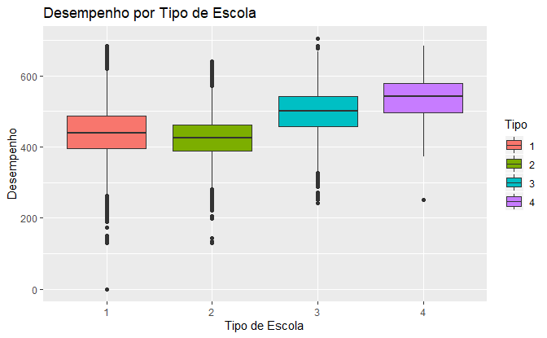

```r
ggplot(data = enem_df, aes(x=as.character(TP_ESCOLA), y=MEDIA , fill = as.character(TP_ESCOLA))) +
  geom_boxplot() +
  labs(title= "Desempenho por Tipo de Escola", x="Tipo de Escola", y = "Desempenho", fill = "Tipo")
```

```r
NA
NA
```

O `summarize ()` faz uso de **aggregate functions**, as quais de um conjunto de valores retorna um único valor. O Base R disponibiliza funções desse tipo, por exêmplo: `min ()`, `max ()`, `mean ()`, `sum ()`, `sd ()`, `median ()`, e `IQR ()`. dplyr fornece outras como:

- `n ()`: o número de observações no grupo atual
- `n_distinct (x)`: o número de valores únicos em `x`.
- `primeiro (x)`, `last (x)` e `nth (x, n)` - que atuam de maneira similar a `x [1]`, `x [length(x)]`, e `x [n]`,póredá a você mais controle sobre o resultado se hover valor faltante.